← Volver al repaso teórico | 📝 Taller en clase | 🏠 Inicio del curso

# Actividad en clase — Retornos y portafolios manuales

## Configuración inicial

```r
if (!require("pacman")) install.packages("pacman")
```

```r
pacman::p_load(tidyverse, EnvStats, ggpubr, psych, quantmod, TTR,
               purrr, PerformanceAnalytics, highcharter, timetk, readxl, scales, htmlwidgets)
options(scipen = 999)

dibujar <- function(p) {
  grid::grid.newpage()
  grid::grid.draw(ggplot2::ggplotGrob(p))
}
```

# 1. Carga de precios y selección de 15 acciones

> “Cargar la información de los precios en R y selecciona 15 acciones del todo el universo.”

**Qué hace**: descarga los precios de cierre de las 40 compañías del enlace del taller, y selecciona 15 de ellas.

**Por qué (teoría)**: se eligen deliberadamente de sectores distintos (tecnología, financiero, salud, consumo básico, industrial, energía) en vez de las 15 primeras de la lista — con 15 acciones del mismo sector el portafolio de la Parte 7 no diversificaría de verdad, se movería casi como un solo activo grande.

```r
url_taller <- "https://raw.githubusercontent.com/salas317/Data/main/TOSF/datos_taller_retornos.csv"

precios_todos <- read_csv(url_taller,
                          col_types = cols(date = col_date(format = "%m/%d/%Y"))) %>%
  timetk::tk_xts(date_var = date)
cat("Universo disponible:", ncol(precios_todos), "acciones,", nrow(precios_todos),
    "días, de", format(zoo::index(precios_todos)[1]), "a",
    format(zoo::index(precios_todos)[nrow(precios_todos)]), "\n")
```

```
## Universo disponible: 40 acciones, 2678 días, de 2015-12-31 a 2026-08-26
```

```r
acciones_15 <- c("AAPL", "MSFT", "NVDA", "GOOGL",   # Tecnología
                  "JPM", "V", "GS",                  # Financiero
                  "LLY", "JNJ", "UNH",                # Salud
                  "WMT", "KO", "PG",                  # Consumo básico
                  "CAT",                               # Industrial
                  "CVX")                               # Energía

precios <- precios_todos[, acciones_15]
head(precios, 3)
```

```
##                AAPL     MSFT      NVDA    GOOGL      JPM        V       GS
## 2015-12-31 23.66844 48.27262 0.8029999 38.55860 49.67610 71.87080 145.4709
## 2016-01-04 23.68867 47.68095 0.7886258 37.63826 48.18407 70.15630 142.9767
## 2016-01-05 23.09505 47.89848 0.8012946 37.74183 48.26739 70.68456 140.5150
##                 LLY      JNJ      UNH      WMT       KO       PG      CAT
## 2015-12-31 70.62955 76.63908 98.88555 16.92268 30.95954 59.00383 52.86848
## 2016-01-04 69.46441 74.96781 97.89368 16.96686 30.55597 58.23109 52.89182
## 2016-01-05 70.50381 75.28118 98.07859 17.36991 30.66407 58.41687 52.33948
##                 CVX
## 2015-12-31 57.05389
## 2016-01-04 56.34989
## 2016-01-05 56.83192
```

# 2. Cálculo de los retornos a distintas frecuencias

> “Calcular los retornos. a. Diarios b. Semanales c. Mensuales d. Trimestrales e. Anuales. Interpreta el resultado de la última observación de cada frecuencia para una de las acciones.”

**Qué hace**: cambia la frecuencia del precio con `to.weekly()`/ `to.monthly()`/`to.quarterly()`/`to.yearly()`, y calcula el retorno continuo —$\ln(P_t/P_{t-1})$— a cada una.

**Por qué (teoría)**: el retorno diario captura solo el último día de negociación; el semanal, todo lo que pasó esa semana; y así hasta el anual, que acumula el año calendario completo. Ninguno es “más correcto” que otro — la frecuencia adecuada depende del horizonte de la decisión que se esté analizando.

```r
# NOTA: diff(log(x)) en vez de TTR::ROC(type="continuous") - con esta misma
# combinacion de librerias (highcharter + PerformanceAnalytics + EnvStats +
# ggpubr + psych + tidyverse todas cargadas juntas), TTR::ROC() sobre un
# objeto de to.weekly()/to.monthly()/etc. crashea R sin ningun mensaje de
# error (ver CLAUDE.md). diff(log(x)) da el mismo resultado matematico y no
# tiene ese problema.

precios_semana <- xts::to.weekly(precios, OHLC = FALSE)
precios_mes <- xts::to.monthly(precios, indexAt = "lastof", OHLC = FALSE)
precios_trimestre <- xts::to.quarterly(precios, indexAt = "lastof", OHLC = FALSE)
precios_anual <- xts::to.yearly(precios, OHLC = FALSE)

retornos_diarios <- diff(log(precios)) %>% na.omit()
retornos_semana <- diff(log(precios_semana)) %>% na.omit()
retornos_mes <- diff(log(precios_mes)) %>% na.omit()
retornos_trimestre <- diff(log(precios_trimestre)) %>% na.omit()
retornos_anual <- diff(log(precios_anual)) %>% na.omit()

ultimo_diario <- as.numeric(tail(retornos_diarios$AAPL, 1))
ultimo_semanal <- as.numeric(tail(retornos_semana$AAPL, 1))
ultimo_mensual <- as.numeric(tail(retornos_mes$AAPL, 1))
ultimo_trimestral <- as.numeric(tail(retornos_trimestre$AAPL, 1))
ultimo_anual <- as.numeric(tail(retornos_anual$AAPL, 1))

data.frame(
  frecuencia = c("Diario", "Semanal", "Mensual", "Trimestral", "Anual"),
  fecha = c(format(zoo::index(tail(retornos_diarios,1))), format(zoo::index(tail(retornos_semana,1))),
            format(zoo::index(tail(retornos_mes,1))), format(zoo::index(tail(retornos_trimestre,1))),
            format(zoo::index(tail(retornos_anual,1)))),
  retorno_AAPL = label_percent(accuracy = 0.01)(c(ultimo_diario, ultimo_semanal, ultimo_mensual,
                                                    ultimo_trimestral, ultimo_anual))
)
```

| frecuencia | fecha | retorno_AAPL |
| --- | --- | --- |
| Diario | 2026-08-26 | 1.14% |
| Semanal | 2026-08-26 | 1.32% |
| Mensual | 2026-08-31 | 1.55% |
| Trimestral | 2026-08-31 | 8.08% |
| Anual | 2026-08-26 | 14.51% |

# 3. Histograma de los retornos semanales de una acción

> “Realiza un histograma de los retornos semanales de una de las acciones.”

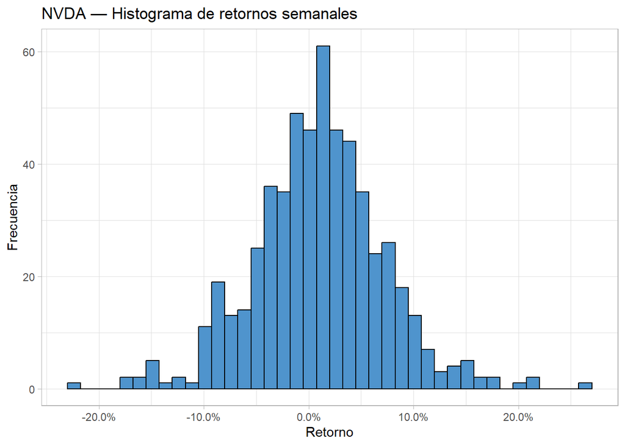

```r
dibujar(ggplot(data.frame(retorno = as.numeric(retornos_semana$NVDA)), aes(x = retorno)) +
  geom_histogram(bins = 40, fill = "steelblue3", color = "black") +
  labs(title = "NVDA — Histograma de retornos semanales", x = "Retorno", y = "Frecuencia") +
  scale_x_continuous(labels = label_percent(0.1)) +
  theme_light())
```

**Respuesta:** se eligió **NVDA** — se ve una distribución con cola derecha más larga que la izquierda (varias semanas con subidas grandes, consistente con su rally reciente en IA), y una dispersión visiblemente mayor que la de acciones más defensivas del grupo (KO, PG, JNJ).

# 4. Histograma de los retornos mensuales de otra acción

> “Realiza un histograma de los retornos mensuales de una de las acciones (diferente de la del punto anterior).”

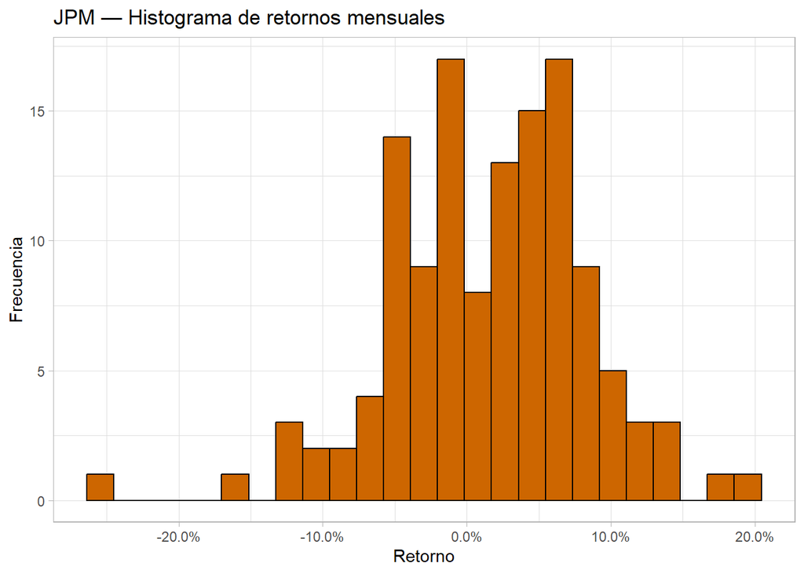

```r
dibujar(ggplot(data.frame(retorno = as.numeric(retornos_mes$JPM)), aes(x = retorno)) +
  geom_histogram(bins = 25, fill = "darkorange3", color = "black") +
  labs(title = "JPM — Histograma de retornos mensuales", x = "Retorno", y = "Frecuencia") +
  scale_x_continuous(labels = label_percent(0.1)) +
  theme_light())
```

# 5. Densidad de los retornos mensuales de 4 acciones

> “Selecciona 4 acciones y realiza un gráfico de densidad de los retornos mensuales.”

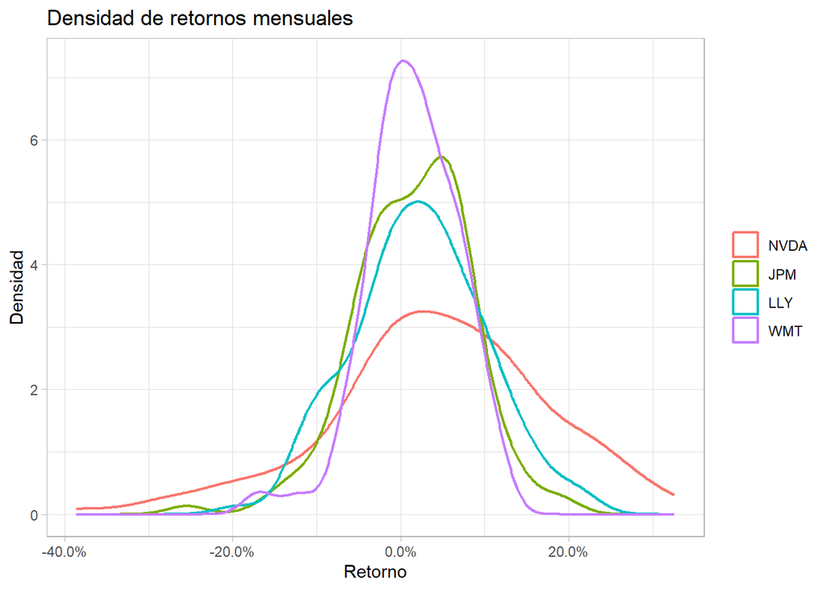

```r
acciones_densidad <- c("NVDA", "JPM", "LLY", "WMT")

retornos_densidad_long <- retornos_mes[, acciones_densidad] %>%
  tk_tbl(rename_index = "date") %>%
  gather(key = activo, value = retorno, -date, factor_key = TRUE)

dibujar(ggplot(retornos_densidad_long, aes(x = retorno, color = activo)) +
  geom_density(linewidth = 0.8) +
  labs(title = "Densidad de retornos mensuales", x = "Retorno", y = "Densidad", color = NULL) +
  scale_x_continuous(labels = label_percent(0.1)) +
  theme_light())
```

# 6. Gráfico dinámico de retornos semanales de 5 acciones

> “Realiza un gráfico dinámico que muestre la evolución de los retornos semanales de 5 acciones.”

**Qué hace**: un gráfico interactivo (zoom, panorámica, exportar) en vez de una imagen estática — útil para explorar de cerca un periodo específico (por ejemplo, la caída de marzo de 2020 o de 2022).

```r
acciones_dinamico <- c("AAPL", "MSFT", "NVDA", "JPM", "CVX")

highcharter::highchart(type = "stock") %>%
  hc_title(text = "Retornos semanales") %>%
  hc_add_series(data = retornos_semana[, acciones_dinamico[1]]*100, name = acciones_dinamico[1]) %>%
  hc_add_series(data = retornos_semana[, acciones_dinamico[2]]*100, name = acciones_dinamico[2]) %>%
  hc_add_series(data = retornos_semana[, acciones_dinamico[3]]*100, name = acciones_dinamico[3]) %>%
  hc_add_series(data = retornos_semana[, acciones_dinamico[4]]*100, name = acciones_dinamico[4]) %>%
  hc_add_series(data = retornos_semana[, acciones_dinamico[5]]*100, name = acciones_dinamico[5]) %>%
  hc_legend(enabled = TRUE) %>%
  hc_add_theme(hc_theme_gridlight()) %>%
  hc_yAxis(labels = list(format = "{value:.1f}%")) %>%
  hc_exporting(enabled = TRUE) %>%
  hc_navigator(height = 10)
```

[interactive chart not shown]

# 7. Portafolio con proporciones diferentes

> “Construya un portafolio a partir de los 15 activos que tiene disponibles (las proporciones deben ser diferentes). Emplee los retornos mensuales.”

**Qué hace**: asigna un peso distinto a cada una de las 15 acciones.

**Por qué (teoría)**: en vez de pesos iguales (1/15 cada una) o arbitrarios, se usa una ponderación de **convicción decreciente** — más peso a las primeras del listado (tecnología de gran capitalización, más líquidas y con más historia de crecimiento) y menos a las últimas — una forma simple y transparente de garantizar 15 pesos genuinamente distintos que además suman exactamente 100%.

```r
w <- rev(seq_along(acciones_15)) / sum(seq_along(acciones_15))
names(w) <- acciones_15

data.frame(accion = acciones_15, peso = label_percent(accuracy = 0.01)(w))
```

|  | accion | peso |
| --- | --- | --- |
| AAPL | AAPL | 12.50% |
| MSFT | MSFT | 11.67% |
| NVDA | NVDA | 10.83% |
| GOOGL | GOOGL | 10.00% |
| JPM | JPM | 9.17% |
| V | V | 8.33% |
| GS | GS | 7.50% |
| LLY | LLY | 6.67% |
| JNJ | JNJ | 5.83% |
| UNH | UNH | 5.00% |

[output cut: 5 more lines]

```r
portafolio_mensual <- PerformanceAnalytics::Return.portfolio(R = retornos_mes,
                                                              weights = w,
                                                              rebalance_on = "months") %>%
  `colnames<-`("retornos")

cat("Portafolio (rebalanceo mensual): retorno mensual promedio =",
    label_percent(accuracy = 0.01)(mean(as.numeric(portafolio_mensual))),
    ", desviación estándar =",
    label_percent(accuracy = 0.01)(sd(as.numeric(portafolio_mensual))), "\n")
```

```
## Portafolio (rebalanceo mensual): retorno mensual promedio = 1.88% , desviación estándar = 4.72%
```

# 8. Rebalanceo mensual vs. anual

> “Calcule los retornos del portafolio con rebalanceos mensuales y otro con rebalanceos anuales.”

**Por qué (teoría)**: rebalancear significa volver a los pesos objetivo periódicamente — sin rebalanceo, los pesos reales se van corriendo solos (la acción que más sube termina pesando más de lo previsto). Rebalancear seguido (mensual) mantiene el portafolio siempre cerca de su composición original; rebalancear poco (anual) deja correr más tiempo a los ganadores antes de recortarlos.

```r
portafolio_anual <- PerformanceAnalytics::Return.portfolio(R = retornos_mes,
                                                            weights = w,
                                                            rebalance_on = "years") %>%
  `colnames<-`("retornos")

tabla_comparacion <- data.frame(
  rebalanceo = c("Mensual", "Anual"),
  retorno_promedio = label_percent(accuracy = 0.01)(c(mean(as.numeric(portafolio_mensual)),
                                                         mean(as.numeric(portafolio_anual)))),
  desv_estandar = label_percent(accuracy = 0.01)(c(sd(as.numeric(portafolio_mensual)),
                                                     sd(as.numeric(portafolio_anual))))
)
tabla_comparacion
```

| rebalanceo | retorno_promedio | desv_estandar |
| --- | --- | --- |
| Mensual | 1.88% | 4.72% |
| Anual | 1.94% | 4.75% |

# 9. Comparación gráfica de las dos series

> “Grafique las dos series de retornos y compare.”

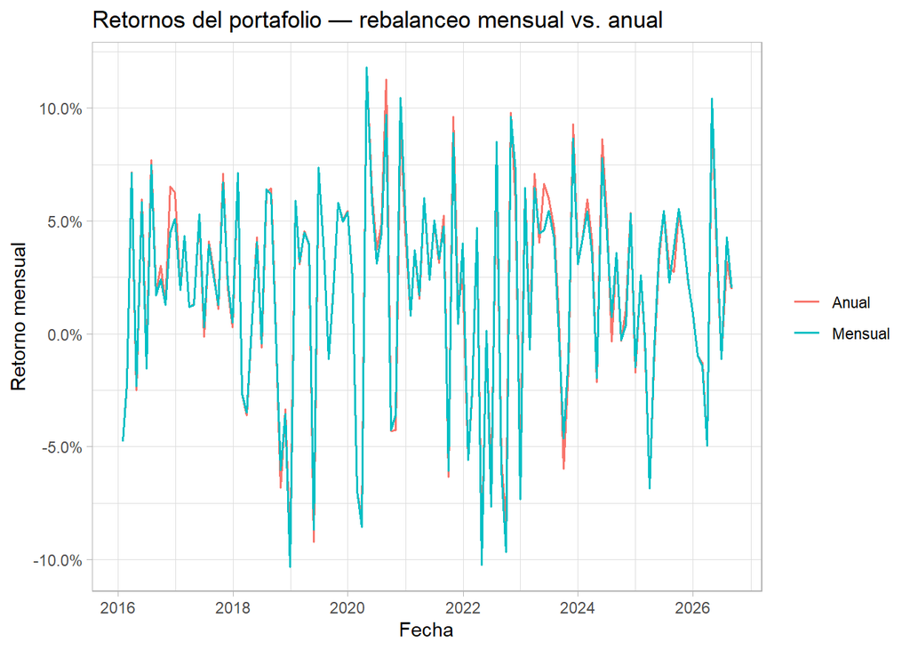

```r
comparacion_long <- bind_rows(
  data.frame(date = zoo::index(portafolio_mensual), retorno = as.numeric(portafolio_mensual), rebalanceo = "Mensual"),
  data.frame(date = zoo::index(portafolio_anual), retorno = as.numeric(portafolio_anual), rebalanceo = "Anual")
)

dibujar(ggplot(comparacion_long, aes(x = date, y = retorno, color = rebalanceo)) +
  geom_line(linewidth = 0.6) +
  labs(title = "Retornos del portafolio — rebalanceo mensual vs. anual",
       x = "Fecha", y = "Retorno mensual", color = NULL) +
  scale_y_continuous(labels = label_percent(0.1)) +
  theme_light())
```

**Respuesta:** las dos series se mueven prácticamente juntas — con solo 15 activos y un año calendario relativamente corto entre rebalanceos, la diferencia entre rebalancear mensual o anualmente es pequeña (0.06% de diferencia en el retorno promedio, y una desviación estándar casi idéntica). La diferencia se nota más en periodos largos con activos de volatilidad muy distinta entre sí — acá, con la mezcla de convicción decreciente elegida, ninguna acción individual llega a dominar tanto el portafolio como para que la frecuencia de rebalanceo cambie el resultado de forma dramática.